# Risk Factor Analysis

## Outcome Variable

**Outcome Variable:** swasted

## Predictor Variables

**Intervention Variable:** mage

**Adjustment Set:**

unadjusted

## Stratifying Variables

The analysis was stratified on these variable(s):

- agecat
- studyid
- country

## Data Summary

| agecat | studyid | country | mage | swasted | n_cell | n |
| --- | --- | --- | --- | --- | --- | --- |
| Birth | ki0047075b-MAL-ED | BANGLADESH | <25 | 0 | 107 | 241 |
| Birth | ki0047075b-MAL-ED | BANGLADESH | <25 | 1 | 2 | 241 |
| Birth | ki0047075b-MAL-ED | BANGLADESH | [25-30) | 0 | 85 | 241 |
| Birth | ki0047075b-MAL-ED | BANGLADESH | [25-30) | 1 | 4 | 241 |
| Birth | ki0047075b-MAL-ED | BANGLADESH | >=30 | 0 | 41 | 241 |
| Birth | ki0047075b-MAL-ED | BANGLADESH | >=30 | 1 | 2 | 241 |
| Birth | ki0047075b-MAL-ED | BRAZIL | <25 | 0 | 94 | 183 |
| Birth | ki0047075b-MAL-ED | BRAZIL | <25 | 1 | 0 | 183 |
| Birth | ki0047075b-MAL-ED | BRAZIL | [25-30) | 0 | 50 | 183 |
| Birth | ki0047075b-MAL-ED | BRAZIL | [25-30) | 1 | 0 | 183 |
| Birth | ki0047075b-MAL-ED | BRAZIL | >=30 | 0 | 39 | 183 |
| Birth | ki0047075b-MAL-ED | BRAZIL | >=30 | 1 | 0 | 183 |
| Birth | ki0047075b-MAL-ED | INDIA | <25 | 0 | 114 | 202 |
| Birth | ki0047075b-MAL-ED | INDIA | <25 | 1 | 6 | 202 |
| Birth | ki0047075b-MAL-ED | INDIA | [25-30) | 0 | 66 | 202 |
| Birth | ki0047075b-MAL-ED | INDIA | [25-30) | 1 | 1 | 202 |
| Birth | ki0047075b-MAL-ED | INDIA | >=30 | 0 | 15 | 202 |
| Birth | ki0047075b-MAL-ED | INDIA | >=30 | 1 | 0 | 202 |
| Birth | ki0047075b-MAL-ED | NEPAL | <25 | 0 | 42 | 168 |
| Birth | ki0047075b-MAL-ED | NEPAL | <25 | 1 | 1 | 168 |
| Birth | ki0047075b-MAL-ED | NEPAL | [25-30) | 0 | 87 | 168 |
| Birth | ki0047075b-MAL-ED | NEPAL | [25-30) | 1 | 3 | 168 |
| Birth | ki0047075b-MAL-ED | NEPAL | >=30 | 0 | 35 | 168 |
| Birth | ki0047075b-MAL-ED | NEPAL | >=30 | 1 | 0 | 168 |
| Birth | ki0047075b-MAL-ED | PERU | <25 | 0 | 155 | 279 |
| Birth | ki0047075b-MAL-ED | PERU | <25 | 1 | 0 | 279 |
| Birth | ki0047075b-MAL-ED | PERU | [25-30) | 0 | 60 | 279 |
| Birth | ki0047075b-MAL-ED | PERU | [25-30) | 1 | 0 | 279 |
| Birth | ki0047075b-MAL-ED | PERU | >=30 | 0 | 64 | 279 |
| Birth | ki0047075b-MAL-ED | PERU | >=30 | 1 | 0 | 279 |

[output cut: 378 more lines]

The following strata were considered:

- agecat: 24 months, studyid: ki0047075b-MAL-ED, country: BANGLADESH
- agecat: 24 months, studyid: ki0047075b-MAL-ED, country: BRAZIL
- agecat: 24 months, studyid: ki0047075b-MAL-ED, country: INDIA
- agecat: 24 months, studyid: ki0047075b-MAL-ED, country: NEPAL
- agecat: 24 months, studyid: ki0047075b-MAL-ED, country: PERU
- agecat: 24 months, studyid: ki0047075b-MAL-ED, country: SOUTH AFRICA
- agecat: 24 months, studyid: ki0047075b-MAL-ED, country: TANZANIA, UNITED REPUBLIC OF
- agecat: 24 months, studyid: ki1000108-CMC-V-BCS-2002, country: INDIA
- agecat: 24 months, studyid: ki1000108-IRC, country: INDIA
- agecat: 24 months, studyid: ki1017093-NIH-Birth, country: BANGLADESH
- agecat: 24 months, studyid: ki1017093b-PROVIDE, country: BANGLADESH
- agecat: 24 months, studyid: ki1017093c-NIH-Crypto, country: BANGLADESH
- agecat: 24 months, studyid: ki1066203-TanzaniaChild2, country: TANZANIA, UNITED REPUBLIC OF
- agecat: 24 months, studyid: ki1101329-Keneba, country: GAMBIA
- agecat: 24 months, studyid: ki1113344-GMS-Nepal, country: NEPAL
- agecat: 24 months, studyid: ki1119695-PROBIT, country: BELARUS
- agecat: 24 months, studyid: ki1126311-ZVITAMBO, country: ZIMBABWE
- agecat: 24 months, studyid: ki1135781-COHORTS, country: GUATEMALA
- agecat: 24 months, studyid: ki1135781-COHORTS, country: INDIA
- agecat: 24 months, studyid: ki1135781-COHORTS, country: PHILIPPINES
- agecat: 24 months, studyid: ki1148112-LCNI-5, country: MALAWI
- agecat: 24 months, studyid: kiGH5241-JiVitA-3, country: BANGLADESH
- agecat: 6 months, studyid: ki0047075b-MAL-ED, country: BANGLADESH
- agecat: 6 months, studyid: ki0047075b-MAL-ED, country: BRAZIL
- agecat: 6 months, studyid: ki0047075b-MAL-ED, country: INDIA
- agecat: 6 months, studyid: ki0047075b-MAL-ED, country: NEPAL
- agecat: 6 months, studyid: ki0047075b-MAL-ED, country: PERU
- agecat: 6 months, studyid: ki0047075b-MAL-ED, country: SOUTH AFRICA
- agecat: 6 months, studyid: ki0047075b-MAL-ED, country: TANZANIA, UNITED REPUBLIC OF
- agecat: 6 months, studyid: ki1000108-CMC-V-BCS-2002, country: INDIA
- agecat: 6 months, studyid: ki1000108-IRC, country: INDIA
- agecat: 6 months, studyid: ki1000109-EE, country: PAKISTAN
- agecat: 6 months, studyid: ki1000304b-SAS-CompFeed, country: INDIA
- agecat: 6 months, studyid: ki1000304b-SAS-FoodSuppl, country: INDIA
- agecat: 6 months, studyid: ki1017093-NIH-Birth, country: BANGLADESH
- agecat: 6 months, studyid: ki1017093b-PROVIDE, country: BANGLADESH
- agecat: 6 months, studyid: ki1017093c-NIH-Crypto, country: BANGLADESH
- agecat: 6 months, studyid: ki1066203-TanzaniaChild2, country: TANZANIA, UNITED REPUBLIC OF
- agecat: 6 months, studyid: ki1101329-Keneba, country: GAMBIA
- agecat: 6 months, studyid: ki1112895-Guatemala BSC, country: GUATEMALA
- agecat: 6 months, studyid: ki1113344-GMS-Nepal, country: NEPAL
- agecat: 6 months, studyid: ki1119695-PROBIT, country: BELARUS
- agecat: 6 months, studyid: ki1126311-ZVITAMBO, country: ZIMBABWE
- agecat: 6 months, studyid: ki1135781-COHORTS, country: GUATEMALA
- agecat: 6 months, studyid: ki1135781-COHORTS, country: INDIA
- agecat: 6 months, studyid: ki1135781-COHORTS, country: PHILIPPINES
- agecat: 6 months, studyid: ki1148112-LCNI-5, country: MALAWI
- agecat: 6 months, studyid: kiGH5241-JiVitA-3, country: BANGLADESH
- agecat: Birth, studyid: ki0047075b-MAL-ED, country: BANGLADESH
- agecat: Birth, studyid: ki0047075b-MAL-ED, country: BRAZIL
- agecat: Birth, studyid: ki0047075b-MAL-ED, country: INDIA
- agecat: Birth, studyid: ki0047075b-MAL-ED, country: NEPAL
- agecat: Birth, studyid: ki0047075b-MAL-ED, country: PERU
- agecat: Birth, studyid: ki0047075b-MAL-ED, country: SOUTH AFRICA
- agecat: Birth, studyid: ki0047075b-MAL-ED, country: TANZANIA, UNITED REPUBLIC OF
- agecat: Birth, studyid: ki1000108-CMC-V-BCS-2002, country: INDIA
- agecat: Birth, studyid: ki1000108-IRC, country: INDIA
- agecat: Birth, studyid: ki1000109-EE, country: PAKISTAN
- agecat: Birth, studyid: ki1000304b-SAS-CompFeed, country: INDIA
- agecat: Birth, studyid: ki1017093-NIH-Birth, country: BANGLADESH
- agecat: Birth, studyid: ki1017093c-NIH-Crypto, country: BANGLADESH
- agecat: Birth, studyid: ki1101329-Keneba, country: GAMBIA
- agecat: Birth, studyid: ki1119695-PROBIT, country: BELARUS
- agecat: Birth, studyid: ki1126311-ZVITAMBO, country: ZIMBABWE
- agecat: Birth, studyid: ki1135781-COHORTS, country: GUATEMALA
- agecat: Birth, studyid: ki1135781-COHORTS, country: INDIA
- agecat: Birth, studyid: ki1135781-COHORTS, country: PHILIPPINES
- agecat: Birth, studyid: kiGH5241-JiVitA-3, country: BANGLADESH

### Dropped Strata

Some strata were dropped due to rare outcomes:

- agecat: Birth, studyid: ki0047075b-MAL-ED, country: BANGLADESH
- agecat: Birth, studyid: ki0047075b-MAL-ED, country: BRAZIL
- agecat: Birth, studyid: ki0047075b-MAL-ED, country: INDIA
- agecat: Birth, studyid: ki0047075b-MAL-ED, country: NEPAL
- agecat: Birth, studyid: ki0047075b-MAL-ED, country: PERU
- agecat: Birth, studyid: ki0047075b-MAL-ED, country: SOUTH AFRICA
- agecat: Birth, studyid: ki0047075b-MAL-ED, country: TANZANIA, UNITED REPUBLIC OF
- agecat: Birth, studyid: ki1000108-CMC-V-BCS-2002, country: INDIA
- agecat: Birth, studyid: ki1000109-EE, country: PAKISTAN
- agecat: Birth, studyid: ki1000304b-SAS-CompFeed, country: INDIA
- agecat: Birth, studyid: ki1017093-NIH-Birth, country: BANGLADESH
- agecat: Birth, studyid: ki1017093c-NIH-Crypto, country: BANGLADESH
- agecat: Birth, studyid: ki1101329-Keneba, country: GAMBIA
- agecat: 6 months, studyid: ki0047075b-MAL-ED, country: BANGLADESH
- agecat: 6 months, studyid: ki0047075b-MAL-ED, country: BRAZIL
- agecat: 6 months, studyid: ki0047075b-MAL-ED, country: INDIA
- agecat: 6 months, studyid: ki0047075b-MAL-ED, country: NEPAL
- agecat: 6 months, studyid: ki0047075b-MAL-ED, country: PERU
- agecat: 6 months, studyid: ki0047075b-MAL-ED, country: SOUTH AFRICA
- agecat: 6 months, studyid: ki0047075b-MAL-ED, country: TANZANIA, UNITED REPUBLIC OF
- agecat: 6 months, studyid: ki1000108-CMC-V-BCS-2002, country: INDIA
- agecat: 6 months, studyid: ki1000108-IRC, country: INDIA
- agecat: 6 months, studyid: ki1000109-EE, country: PAKISTAN
- agecat: 6 months, studyid: ki1017093-NIH-Birth, country: BANGLADESH
- agecat: 6 months, studyid: ki1017093b-PROVIDE, country: BANGLADESH
- agecat: 6 months, studyid: ki1017093c-NIH-Crypto, country: BANGLADESH
- agecat: 6 months, studyid: ki1066203-TanzaniaChild2, country: TANZANIA, UNITED REPUBLIC OF
- agecat: 6 months, studyid: ki1112895-Guatemala BSC, country: GUATEMALA
- agecat: 6 months, studyid: ki1113344-GMS-Nepal, country: NEPAL
- agecat: 6 months, studyid: ki1119695-PROBIT, country: BELARUS
- agecat: 6 months, studyid: ki1135781-COHORTS, country: GUATEMALA
- agecat: 6 months, studyid: ki1148112-LCNI-5, country: MALAWI
- agecat: 24 months, studyid: ki0047075b-MAL-ED, country: BANGLADESH
- agecat: 24 months, studyid: ki0047075b-MAL-ED, country: BRAZIL
- agecat: 24 months, studyid: ki0047075b-MAL-ED, country: INDIA
- agecat: 24 months, studyid: ki0047075b-MAL-ED, country: NEPAL
- agecat: 24 months, studyid: ki0047075b-MAL-ED, country: PERU
- agecat: 24 months, studyid: ki0047075b-MAL-ED, country: SOUTH AFRICA
- agecat: 24 months, studyid: ki0047075b-MAL-ED, country: TANZANIA, UNITED REPUBLIC OF
- agecat: 24 months, studyid: ki1000108-CMC-V-BCS-2002, country: INDIA
- agecat: 24 months, studyid: ki1000108-IRC, country: INDIA
- agecat: 24 months, studyid: ki1017093-NIH-Birth, country: BANGLADESH
- agecat: 24 months, studyid: ki1017093b-PROVIDE, country: BANGLADESH
- agecat: 24 months, studyid: ki1017093c-NIH-Crypto, country: BANGLADESH
- agecat: 24 months, studyid: ki1066203-TanzaniaChild2, country: TANZANIA, UNITED REPUBLIC OF
- agecat: 24 months, studyid: ki1113344-GMS-Nepal, country: NEPAL
- agecat: 24 months, studyid: ki1119695-PROBIT, country: BELARUS
- agecat: 24 months, studyid: ki1135781-COHORTS, country: GUATEMALA
- agecat: 24 months, studyid: ki1148112-LCNI-5, country: MALAWI

## Methods Detail

We’re interested in the causal parameters $E[Y_a]$ for all values of $a \in \mathcal{A}$. These parameters represent the mean outcome if, possibly contrary to fact, we intervened to set all units to have $A=a$. Under the randomization and positivity assumptions, these are identified by the statistical parameters $\psi_a=E_W[E_{Y|A,W}(Y|A=a,W)]$. In addition, we’re interested in the mean of $Y$, $E[Y]$ under no intervention (the observed mean). We will estimate these parameters by using SuperLearner to fit the relevant likelihood factors – $E_{Y|A,W}(Y|A=a,W)$ and $p(A=a|W)$, and then updating our likelihood fit using a joint TMLE.

For unadjusted analyses ($W=\{\}$), initial likelihoods were estimated using Lrnr_glm to estimate the simple $E(Y|A)$ and Lrnr_mean to estimate $p(A)$. For adjusted analyses, a small library containing Lrnr_glmnet, Lrnr_xgboost, and Lrnr_mean was used.

Having estimated these parameters, we will then use the delta method to estimate relative risks and attributable risks relative to a prespecified baseline level of $A$.

# Results Detail

## Results Plots

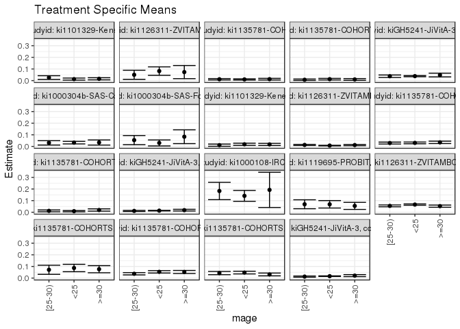

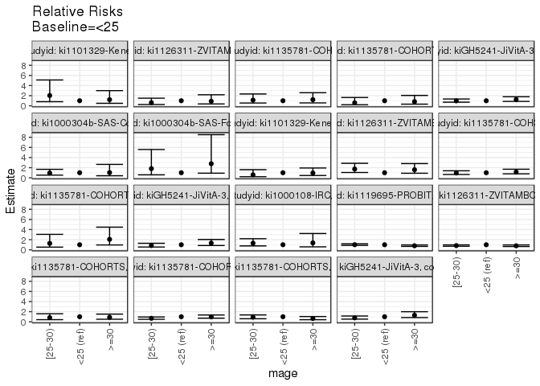

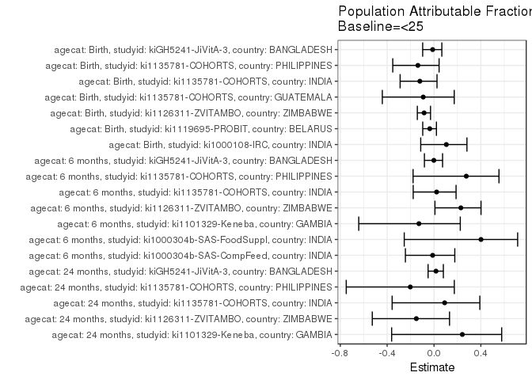

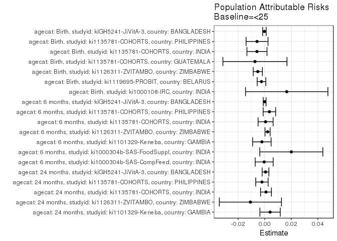

## Results Table

### Parameter: TSM

| agecat | studyid | country | intervention_level | baseline_level | estimate | ci_lower | ci_upper |
| --- | --- | --- | --- | --- | --- | --- | --- |
| Birth | ki1000108-IRC | INDIA | <25 | NA | 0.1408451 | 0.0940609 | 0.1876292 |
| Birth | ki1000108-IRC | INDIA | [25-30) | NA | 0.1826923 | 0.1083188 | 0.2570658 |
| Birth | ki1000108-IRC | INDIA | >=30 | NA | 0.1923077 | 0.0405968 | 0.3440186 |
| Birth | ki1119695-PROBIT | BELARUS | <25 | NA | 0.0682828 | 0.0362998 | 0.1002659 |
| Birth | ki1119695-PROBIT | BELARUS | [25-30) | NA | 0.0686983 | 0.0303004 | 0.1070963 |
| Birth | ki1119695-PROBIT | BELARUS | >=30 | NA | 0.0546102 | 0.0240624 | 0.0851581 |
| Birth | ki1126311-ZVITAMBO | ZIMBABWE | <25 | NA | 0.0661863 | 0.0605574 | 0.0718152 |
| Birth | ki1126311-ZVITAMBO | ZIMBABWE | [25-30) | NA | 0.0547434 | 0.0468799 | 0.0626069 |
| Birth | ki1126311-ZVITAMBO | ZIMBABWE | >=30 | NA | 0.0525104 | 0.0431273 | 0.0618934 |
| Birth | ki1135781-COHORTS | GUATEMALA | <25 | NA | 0.0866667 | 0.0548089 | 0.1185245 |
| Birth | ki1135781-COHORTS | GUATEMALA | [25-30) | NA | 0.0714286 | 0.0324591 | 0.1103980 |
| Birth | ki1135781-COHORTS | GUATEMALA | >=30 | NA | 0.0763889 | 0.0456917 | 0.1070861 |
| Birth | ki1135781-COHORTS | INDIA | <25 | NA | 0.0536876 | 0.0433987 | 0.0639766 |
| Birth | ki1135781-COHORTS | INDIA | [25-30) | NA | 0.0370370 | 0.0273422 | 0.0467319 |
| Birth | ki1135781-COHORTS | INDIA | >=30 | NA | 0.0525839 | 0.0394102 | 0.0657575 |
| Birth | ki1135781-COHORTS | PHILIPPINES | <25 | NA | 0.0474708 | 0.0358423 | 0.0590993 |
| Birth | ki1135781-COHORTS | PHILIPPINES | [25-30) | NA | 0.0430504 | 0.0290960 | 0.0570048 |
| Birth | ki1135781-COHORTS | PHILIPPINES | >=30 | NA | 0.0312110 | 0.0191669 | 0.0432551 |
| Birth | kiGH5241-JiVitA-3 | BANGLADESH | <25 | NA | 0.0163646 | 0.0137052 | 0.0190240 |
| Birth | kiGH5241-JiVitA-3 | BANGLADESH | [25-30) | NA | 0.0127524 | 0.0079952 | 0.0175096 |
| Birth | kiGH5241-JiVitA-3 | BANGLADESH | >=30 | NA | 0.0211500 | 0.0125951 | 0.0297050 |
| 6 months | ki1000304b-SAS-CompFeed | INDIA | <25 | NA | 0.0326087 | 0.0216042 | 0.0436132 |
| 6 months | ki1000304b-SAS-CompFeed | INDIA | [25-30) | NA | 0.0307263 | 0.0119739 | 0.0494786 |
| 6 months | ki1000304b-SAS-CompFeed | INDIA | >=30 | NA | 0.0337838 | 0.0117744 | 0.0557931 |
| 6 months | ki1000304b-SAS-FoodSuppl | INDIA | <25 | NA | 0.0299401 | 0.0040587 | 0.0558215 |
| 6 months | ki1000304b-SAS-FoodSuppl | INDIA | [25-30) | NA | 0.0542636 | 0.0151196 | 0.0934075 |
| 6 months | ki1000304b-SAS-FoodSuppl | INDIA | >=30 | NA | 0.0833333 | 0.0241505 | 0.1425162 |
| 6 months | ki1101329-Keneba | GAMBIA | <25 | NA | 0.0184502 | 0.0091976 | 0.0277028 |
| 6 months | ki1101329-Keneba | GAMBIA | [25-30) | NA | 0.0108225 | 0.0013855 | 0.0202595 |
| 6 months | ki1101329-Keneba | GAMBIA | >=30 | NA | 0.0173913 | 0.0083587 | 0.0264239 |
| 6 months | ki1126311-ZVITAMBO | ZIMBABWE | <25 | NA | 0.0073801 | 0.0049084 | 0.0098517 |
| 6 months | ki1126311-ZVITAMBO | ZIMBABWE | [25-30) | NA | 0.0127901 | 0.0079964 | 0.0175839 |
| 6 months | ki1126311-ZVITAMBO | ZIMBABWE | >=30 | NA | 0.0117570 | 0.0063573 | 0.0171567 |
| 6 months | ki1135781-COHORTS | INDIA | <25 | NA | 0.0303468 | 0.0229670 | 0.0377266 |
| 6 months | ki1135781-COHORTS | INDIA | [25-30) | NA | 0.0289944 | 0.0208254 | 0.0371635 |
| 6 months | ki1135781-COHORTS | INDIA | >=30 | NA | 0.0350000 | 0.0246008 | 0.0453992 |
| 6 months | ki1135781-COHORTS | PHILIPPINES | <25 | NA | 0.0093697 | 0.0038576 | 0.0148817 |
| 6 months | ki1135781-COHORTS | PHILIPPINES | [25-30) | NA | 0.0118890 | 0.0041666 | 0.0196115 |
| 6 months | ki1135781-COHORTS | PHILIPPINES | >=30 | NA | 0.0193548 | 0.0096536 | 0.0290561 |
| 6 months | kiGH5241-JiVitA-3 | BANGLADESH | <25 | NA | 0.0137261 | 0.0113269 | 0.0161253 |
| 6 months | kiGH5241-JiVitA-3 | BANGLADESH | [25-30) | NA | 0.0115741 | 0.0071126 | 0.0160355 |
| 6 months | kiGH5241-JiVitA-3 | BANGLADESH | >=30 | NA | 0.0180476 | 0.0107349 | 0.0253602 |
| 24 months | ki1101329-Keneba | GAMBIA | <25 | NA | 0.0128205 | 0.0039911 | 0.0216500 |
| 24 months | ki1101329-Keneba | GAMBIA | [25-30) | NA | 0.0260417 | 0.0101081 | 0.0419753 |
| 24 months | ki1101329-Keneba | GAMBIA | >=30 | NA | 0.0155587 | 0.0064334 | 0.0246840 |
| 24 months | ki1126311-ZVITAMBO | ZIMBABWE | <25 | NA | 0.0818182 | 0.0455571 | 0.1180793 |
| 24 months | ki1126311-ZVITAMBO | ZIMBABWE | [25-30) | NA | 0.0500000 | 0.0109591 | 0.0890409 |
| 24 months | ki1126311-ZVITAMBO | ZIMBABWE | >=30 | NA | 0.0731707 | 0.0167388 | 0.1296027 |
| 24 months | ki1135781-COHORTS | INDIA | <25 | NA | 0.0101695 | 0.0050486 | 0.0152903 |
| 24 months | ki1135781-COHORTS | INDIA | [25-30) | NA | 0.0115037 | 0.0055117 | 0.0174956 |
| 24 months | ki1135781-COHORTS | INDIA | >=30 | NA | 0.0123330 | 0.0053973 | 0.0192687 |
| 24 months | ki1135781-COHORTS | PHILIPPINES | <25 | NA | 0.0122757 | 0.0056424 | 0.0189090 |
| 24 months | ki1135781-COHORTS | PHILIPPINES | [25-30) | NA | 0.0071942 | 0.0009098 | 0.0134787 |
| 24 months | ki1135781-COHORTS | PHILIPPINES | >=30 | NA | 0.0100719 | 0.0026468 | 0.0174971 |
| 24 months | kiGH5241-JiVitA-3 | BANGLADESH | <25 | NA | 0.0383077 | 0.0333566 | 0.0432588 |
| 24 months | kiGH5241-JiVitA-3 | BANGLADESH | [25-30) | NA | 0.0375180 | 0.0267244 | 0.0483117 |
| 24 months | kiGH5241-JiVitA-3 | BANGLADESH | >=30 | NA | 0.0477528 | 0.0317831 | 0.0637225 |

### Parameter: E(Y)

| agecat | studyid | country | intervention_level | baseline_level | estimate | ci_lower | ci_upper |
| --- | --- | --- | --- | --- | --- | --- | --- |
| Birth | ki1000108-IRC | INDIA | NA | NA | 0.1574344 | 0.1188345 | 0.1960344 |
| Birth | ki1119695-PROBIT | BELARUS | NA | NA | 0.0658999 | 0.0328405 | 0.0989593 |
| Birth | ki1126311-ZVITAMBO | ZIMBABWE | NA | NA | 0.0610248 | 0.0568907 | 0.0651590 |
| Birth | ki1135781-COHORTS | GUATEMALA | NA | NA | 0.0793651 | 0.0600839 | 0.0986462 |
| Birth | ki1135781-COHORTS | INDIA | NA | NA | 0.0479001 | 0.0415930 | 0.0542073 |
| Birth | ki1135781-COHORTS | PHILIPPINES | NA | NA | 0.0417385 | 0.0344572 | 0.0490198 |
| Birth | kiGH5241-JiVitA-3 | BANGLADESH | NA | NA | 0.0161763 | 0.0138129 | 0.0185396 |
| 6 months | ki1000304b-SAS-CompFeed | INDIA | NA | NA | 0.0322339 | 0.0235219 | 0.0409459 |
| 6 months | ki1000304b-SAS-FoodSuppl | INDIA | NA | NA | 0.0500000 | 0.0280580 | 0.0719420 |
| 6 months | ki1101329-Keneba | GAMBIA | NA | NA | 0.0163462 | 0.0108955 | 0.0217968 |
| 6 months | ki1126311-ZVITAMBO | ZIMBABWE | NA | NA | 0.0095769 | 0.0074751 | 0.0116787 |
| 6 months | ki1135781-COHORTS | INDIA | NA | NA | 0.0310394 | 0.0261816 | 0.0358972 |
| 6 months | ki1135781-COHORTS | PHILIPPINES | NA | NA | 0.0129342 | 0.0086762 | 0.0171922 |
| 6 months | kiGH5241-JiVitA-3 | BANGLADESH | NA | NA | 0.0137076 | 0.0116310 | 0.0157842 |
| 24 months | ki1101329-Keneba | GAMBIA | NA | NA | 0.0169096 | 0.0108057 | 0.0230135 |
| 24 months | ki1126311-ZVITAMBO | ZIMBABWE | NA | NA | 0.0710900 | 0.0465431 | 0.0956370 |
| 24 months | ki1135781-COHORTS | INDIA | NA | NA | 0.0111869 | 0.0077814 | 0.0145924 |
| 24 months | ki1135781-COHORTS | PHILIPPINES | NA | NA | 0.0102082 | 0.0062264 | 0.0141901 |
| 24 months | kiGH5241-JiVitA-3 | BANGLADESH | NA | NA | 0.0389625 | 0.0346386 | 0.0432864 |

### Parameter: RR

| agecat | studyid | country | intervention_level | baseline_level | estimate | ci_lower | ci_upper |
| --- | --- | --- | --- | --- | --- | --- | --- |
| Birth | ki1000108-IRC | INDIA | <25 | <25 | 1.0000000 | 1.0000000 | 1.0000000 |
| Birth | ki1000108-IRC | INDIA | [25-30) | <25 | 1.2971154 | 0.7669954 | 2.1936355 |
| Birth | ki1000108-IRC | INDIA | >=30 | <25 | 1.3653846 | 0.5801093 | 3.2136620 |
| Birth | ki1119695-PROBIT | BELARUS | <25 | <25 | 1.0000000 | 1.0000000 | 1.0000000 |
| Birth | ki1119695-PROBIT | BELARUS | [25-30) | <25 | 1.0060853 | 0.8561130 | 1.1823294 |
| Birth | ki1119695-PROBIT | BELARUS | >=30 | <25 | 0.7997649 | 0.6660671 | 0.9602994 |
| Birth | ki1126311-ZVITAMBO | ZIMBABWE | <25 | <25 | 1.0000000 | 1.0000000 | 1.0000000 |
| Birth | ki1126311-ZVITAMBO | ZIMBABWE | [25-30) | <25 | 0.8271108 | 0.6999490 | 0.9773746 |
| Birth | ki1126311-ZVITAMBO | ZIMBABWE | >=30 | <25 | 0.7933723 | 0.6509263 | 0.9669906 |
| Birth | ki1135781-COHORTS | GUATEMALA | <25 | <25 | 1.0000000 | 1.0000000 | 1.0000000 |
| Birth | ki1135781-COHORTS | GUATEMALA | [25-30) | <25 | 0.8241758 | 0.4268915 | 1.5911905 |
| Birth | ki1135781-COHORTS | GUATEMALA | >=30 | <25 | 0.8814103 | 0.5112735 | 1.5195076 |
| Birth | ki1135781-COHORTS | INDIA | <25 | <25 | 1.0000000 | 1.0000000 | 1.0000000 |
| Birth | ki1135781-COHORTS | INDIA | [25-30) | <25 | 0.6898616 | 0.4987343 | 0.9542335 |
| Birth | ki1135781-COHORTS | INDIA | >=30 | <25 | 0.9794408 | 0.7144832 | 1.3426549 |
| Birth | ki1135781-COHORTS | PHILIPPINES | <25 | <25 | 1.0000000 | 1.0000000 | 1.0000000 |
| Birth | ki1135781-COHORTS | PHILIPPINES | [25-30) | <25 | 0.9068820 | 0.6040883 | 1.3614483 |
| Birth | ki1135781-COHORTS | PHILIPPINES | >=30 | <25 | 0.6574773 | 0.4162694 | 1.0384534 |
| Birth | kiGH5241-JiVitA-3 | BANGLADESH | <25 | <25 | 1.0000000 | 1.0000000 | 1.0000000 |
| Birth | kiGH5241-JiVitA-3 | BANGLADESH | [25-30) | <25 | 0.7792671 | 0.5296996 | 1.1464180 |
| Birth | kiGH5241-JiVitA-3 | BANGLADESH | >=30 | <25 | 1.2924262 | 0.8371961 | 1.9951904 |
| 6 months | ki1000304b-SAS-CompFeed | INDIA | <25 | <25 | 1.0000000 | 1.0000000 | 1.0000000 |
| 6 months | ki1000304b-SAS-CompFeed | INDIA | [25-30) | <25 | 0.9422719 | 0.5307920 | 1.6727388 |
| 6 months | ki1000304b-SAS-CompFeed | INDIA | >=30 | <25 | 1.0360360 | 0.4060111 | 2.6436976 |
| 6 months | ki1000304b-SAS-FoodSuppl | INDIA | <25 | <25 | 1.0000000 | 1.0000000 | 1.0000000 |
| 6 months | ki1000304b-SAS-FoodSuppl | INDIA | [25-30) | <25 | 1.8124031 | 0.5878783 | 5.5875595 |
| 6 months | ki1000304b-SAS-FoodSuppl | INDIA | >=30 | <25 | 2.7833333 | 0.9092694 | 8.5199663 |
| 6 months | ki1101329-Keneba | GAMBIA | <25 | <25 | 1.0000000 | 1.0000000 | 1.0000000 |
| 6 months | ki1101329-Keneba | GAMBIA | [25-30) | <25 | 0.5865801 | 0.2145213 | 1.6039259 |
| 6 months | ki1101329-Keneba | GAMBIA | >=30 | <25 | 0.9426087 | 0.4579139 | 1.9403454 |
| 6 months | ki1126311-ZVITAMBO | ZIMBABWE | <25 | <25 | 1.0000000 | 1.0000000 | 1.0000000 |
| 6 months | ki1126311-ZVITAMBO | ZIMBABWE | [25-30) | <25 | 1.7330649 | 1.0483956 | 2.8648670 |
| 6 months | ki1126311-ZVITAMBO | ZIMBABWE | >=30 | <25 | 1.5930764 | 0.9023551 | 2.8125208 |
| 6 months | ki1135781-COHORTS | INDIA | <25 | <25 | 1.0000000 | 1.0000000 | 1.0000000 |
| 6 months | ki1135781-COHORTS | INDIA | [25-30) | <25 | 0.9554361 | 0.6585164 | 1.3862344 |
| 6 months | ki1135781-COHORTS | INDIA | >=30 | <25 | 1.1533333 | 0.7856112 | 1.6931758 |
| 6 months | ki1135781-COHORTS | PHILIPPINES | <25 | <25 | 1.0000000 | 1.0000000 | 1.0000000 |
| 6 months | ki1135781-COHORTS | PHILIPPINES | [25-30) | <25 | 1.2688844 | 0.5282361 | 3.0480075 |
| 6 months | ki1135781-COHORTS | PHILIPPINES | >=30 | <25 | 2.0656891 | 0.9537095 | 4.4741839 |
| 6 months | kiGH5241-JiVitA-3 | BANGLADESH | <25 | <25 | 1.0000000 | 1.0000000 | 1.0000000 |
| 6 months | kiGH5241-JiVitA-3 | BANGLADESH | [25-30) | <25 | 0.8432168 | 0.5526070 | 1.2866550 |
| 6 months | kiGH5241-JiVitA-3 | BANGLADESH | >=30 | <25 | 1.3148372 | 0.8478118 | 2.0391280 |
| 24 months | ki1101329-Keneba | GAMBIA | <25 | <25 | 1.0000000 | 1.0000000 | 1.0000000 |
| 24 months | ki1101329-Keneba | GAMBIA | [25-30) | <25 | 2.0312500 | 0.8084974 | 5.1032648 |
| 24 months | ki1101329-Keneba | GAMBIA | >=30 | <25 | 1.2135785 | 0.4911419 | 2.9986708 |
| 24 months | ki1126311-ZVITAMBO | ZIMBABWE | <25 | <25 | 1.0000000 | 1.0000000 | 1.0000000 |
| 24 months | ki1126311-ZVITAMBO | ZIMBABWE | [25-30) | <25 | 0.6111111 | 0.2489996 | 1.4998290 |
| 24 months | ki1126311-ZVITAMBO | ZIMBABWE | >=30 | <25 | 0.8943089 | 0.3674339 | 2.1766867 |
| 24 months | ki1135781-COHORTS | INDIA | <25 | <25 | 1.0000000 | 1.0000000 | 1.0000000 |
| 24 months | ki1135781-COHORTS | INDIA | [25-30) | <25 | 1.1311969 | 0.5481521 | 2.3344004 |
| 24 months | ki1135781-COHORTS | INDIA | >=30 | <25 | 1.2127441 | 0.5700793 | 2.5799012 |
| 24 months | ki1135781-COHORTS | PHILIPPINES | <25 | <25 | 1.0000000 | 1.0000000 | 1.0000000 |
| 24 months | ki1135781-COHORTS | PHILIPPINES | [25-30) | <25 | 0.5860542 | 0.2098198 | 1.6369266 |
| 24 months | ki1135781-COHORTS | PHILIPPINES | >=30 | <25 | 0.8204759 | 0.3289310 | 2.0465716 |
| 24 months | kiGH5241-JiVitA-3 | BANGLADESH | <25 | <25 | 1.0000000 | 1.0000000 | 1.0000000 |
| 24 months | kiGH5241-JiVitA-3 | BANGLADESH | [25-30) | <25 | 0.9793865 | 0.7139253 | 1.3435551 |
| 24 months | kiGH5241-JiVitA-3 | BANGLADESH | >=30 | <25 | 1.2465593 | 0.8696447 | 1.7868333 |

### Parameter: PAR

| agecat | studyid | country | intervention_level | baseline_level | estimate | ci_lower | ci_upper |
| --- | --- | --- | --- | --- | --- | --- | --- |
| Birth | ki1000108-IRC | INDIA | <25 | NA | 0.0165893 | -0.0143996 | 0.0475783 |
| Birth | ki1119695-PROBIT | BELARUS | <25 | NA | -0.0023829 | -0.0056215 | 0.0008556 |
| Birth | ki1126311-ZVITAMBO | ZIMBABWE | <25 | NA | -0.0051614 | -0.0086119 | -0.0017110 |
| Birth | ki1135781-COHORTS | GUATEMALA | <25 | NA | -0.0073016 | -0.0314095 | 0.0168063 |
| Birth | ki1135781-COHORTS | INDIA | <25 | NA | -0.0057875 | -0.0133381 | 0.0017631 |
| Birth | ki1135781-COHORTS | PHILIPPINES | <25 | NA | -0.0057323 | -0.0140005 | 0.0025359 |
| Birth | kiGH5241-JiVitA-3 | BANGLADESH | <25 | NA | -0.0001883 | -0.0015079 | 0.0011313 |
| 6 months | ki1000304b-SAS-CompFeed | INDIA | <25 | NA | -0.0003748 | -0.0071232 | 0.0063736 |
| 6 months | ki1000304b-SAS-FoodSuppl | INDIA | <25 | NA | 0.0200599 | -0.0036580 | 0.0437777 |
| 6 months | ki1101329-Keneba | GAMBIA | <25 | NA | -0.0021040 | -0.0090608 | 0.0048527 |
| 6 months | ki1126311-ZVITAMBO | ZIMBABWE | <25 | NA | 0.0021968 | 0.0002725 | 0.0041212 |
| 6 months | ki1135781-COHORTS | INDIA | <25 | NA | 0.0006926 | -0.0049539 | 0.0063391 |
| 6 months | ki1135781-COHORTS | PHILIPPINES | <25 | NA | 0.0035645 | -0.0011419 | 0.0082710 |
| 6 months | kiGH5241-JiVitA-3 | BANGLADESH | <25 | NA | -0.0000185 | -0.0010809 | 0.0010439 |
| 24 months | ki1101329-Keneba | GAMBIA | <25 | NA | 0.0040891 | -0.0035585 | 0.0117367 |
| 24 months | ki1126311-ZVITAMBO | ZIMBABWE | <25 | NA | -0.0107281 | -0.0341048 | 0.0126486 |
| 24 months | ki1135781-COHORTS | INDIA | <25 | NA | 0.0010174 | -0.0030708 | 0.0051056 |
| 24 months | ki1135781-COHORTS | PHILIPPINES | <25 | NA | -0.0020675 | -0.0067368 | 0.0026018 |
| 24 months | kiGH5241-JiVitA-3 | BANGLADESH | <25 | NA | 0.0006549 | -0.0018846 | 0.0031943 |

### Parameter: PAF

| agecat | studyid | country | intervention_level | baseline_level | estimate | ci_lower | ci_upper |
| --- | --- | --- | --- | --- | --- | --- | --- |
| Birth | ki1000108-IRC | INDIA | <25 | NA | 0.1053730 | -0.1133883 | 0.2811515 |
| Birth | ki1119695-PROBIT | BELARUS | <25 | NA | -0.0361601 | -0.0962724 | 0.0206561 |
| Birth | ki1126311-ZVITAMBO | ZIMBABWE | <25 | NA | -0.0845793 | -0.1423577 | -0.0297232 |
| Birth | ki1135781-COHORTS | GUATEMALA | <25 | NA | -0.0920000 | -0.4413310 | 0.1726647 |
| Birth | ki1135781-COHORTS | INDIA | <25 | NA | -0.1208248 | -0.2892585 | 0.0256041 |
| Birth | ki1135781-COHORTS | PHILIPPINES | <25 | NA | -0.1373380 | -0.3521742 | 0.0433646 |
| Birth | kiGH5241-JiVitA-3 | BANGLADESH | <25 | NA | -0.0116413 | -0.0966894 | 0.0668113 |
| 6 months | ki1000304b-SAS-CompFeed | INDIA | <25 | NA | -0.0116279 | -0.2442645 | 0.1775133 |
| 6 months | ki1000304b-SAS-FoodSuppl | INDIA | <25 | NA | 0.4011976 | -0.2541546 | 0.7140988 |
| 6 months | ki1101329-Keneba | GAMBIA | <25 | NA | -0.1287172 | -0.6426090 | 0.2244031 |
| 6 months | ki1126311-ZVITAMBO | ZIMBABWE | <25 | NA | 0.2293895 | 0.0079853 | 0.4013793 |
| 6 months | ki1135781-COHORTS | INDIA | <25 | NA | 0.0223133 | -0.1775884 | 0.1882806 |
| 6 months | ki1135781-COHORTS | PHILIPPINES | <25 | NA | 0.2755902 | -0.1786226 | 0.5547603 |
| 6 months | kiGH5241-JiVitA-3 | BANGLADESH | <25 | NA | -0.0013485 | -0.0819183 | 0.0732213 |
| 24 months | ki1101329-Keneba | GAMBIA | <25 | NA | 0.2418214 | -0.3617304 | 0.5778645 |
| 24 months | ki1126311-ZVITAMBO | ZIMBABWE | <25 | NA | -0.1509091 | -0.5269872 | 0.1325456 |
| 24 months | ki1135781-COHORTS | INDIA | <25 | NA | 0.0909467 | -0.3573342 | 0.3911758 |
| 24 months | ki1135781-COHORTS | PHILIPPINES | <25 | NA | -0.2025307 | -0.7493157 | 0.1733453 |
| 24 months | kiGH5241-JiVitA-3 | BANGLADESH | <25 | NA | 0.0168073 | -0.0505496 | 0.0798456 |